# Linear Regression / week 2

*Describe the work you have done this week and summarize your learning.*

In this course we use a dataset that is a subset of another dataset with more variables. The original dataset was used to study learning and teaching of statistics. The variables in this dataset (other than age, gender and points), are means of answers to questions that related to the specific themes (such as attitude). Our dataset has 166 subjects and 8 variables. 17 subjects were excluded because of not having any exam points.

Let’s read in the dataset from the data folder:

```r
learning2014 <- read.csv("./data/learning2014.csv")
```

**Visualization of the data in a matrix of plots** Genders have their own color (blue=male, pink=female).

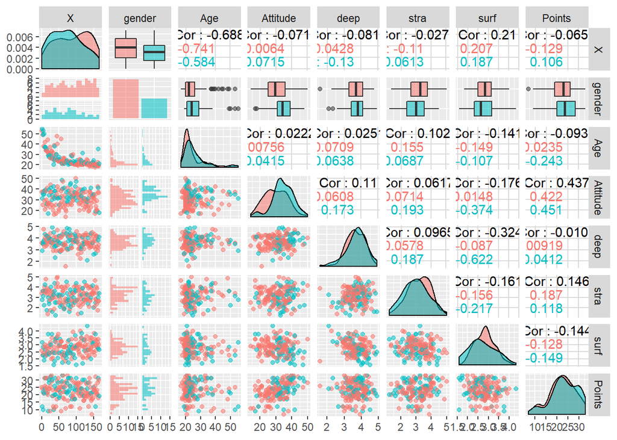

```r
ggpairs(learning2014, mapping = aes(col=gender, alpha=0.3), lower = list(combo = wrap("facethist", bins = 20)), progress=FALSE)
```

From the correlations we can see that attitude seems to have some correlation with exam points. This can also be seen from the scatterplots, where there seems to be a linear relationship between points and attitude.Other variables don’t seem to have clear correlation.

**Summaries of the data**

```r
summary(learning2014)
```

```
##        X          gender       Age           Attitude          deep
##  Min.   :  1.00   F:110   Min.   :17.00   Min.   :14.00   Min.   :1.583
##  1st Qu.: 42.25   M: 56   1st Qu.:21.00   1st Qu.:26.00   1st Qu.:3.333
##  Median : 83.50           Median :22.00   Median :32.00   Median :3.667
##  Mean   : 83.50           Mean   :25.51   Mean   :31.43   Mean   :3.680
##  3rd Qu.:124.75           3rd Qu.:27.00   3rd Qu.:37.00   3rd Qu.:4.083
##  Max.   :166.00           Max.   :55.00   Max.   :50.00   Max.   :4.917
##       stra            surf           Points
##  Min.   :1.250   Min.   :1.583   Min.   : 7.00
##  1st Qu.:2.625   1st Qu.:2.417   1st Qu.:19.00
##  Median :3.188   Median :2.833   Median :23.00
##  Mean   :3.121   Mean   :2.787   Mean   :22.72
##  3rd Qu.:3.625   3rd Qu.:3.167   3rd Qu.:27.75
##  Max.   :5.000   Max.   :4.333   Max.   :33.00
```

From the summaries (and plots) we can see that there is almost twize as much females as there are males. The mean age is 25.5 years, but the subjects varied from 17-55 years old.

**Regression model with three explanatory variables (attitude, stra and surf) and exam points as the target** The explanatory variables were chosen based on their correlation with the points in the plot matrix.

```r
model <- lm(Points~ Attitude + stra + surf, data= learning2014)
summary(model)
```

```
##
## Call:
## lm(formula = Points ~ Attitude + stra + surf, data = learning2014)
##
## Residuals:
##      Min       1Q   Median       3Q      Max
## -17.1550  -3.4346   0.5156   3.6401  10.8952
##
## Coefficients:
##             Estimate Std. Error t value Pr(>|t|)
## (Intercept) 11.01711    3.68375   2.991  0.00322 **
## Attitude     0.33952    0.05741   5.913 1.93e-08 ***
## stra         0.85313    0.54159   1.575  0.11716
## surf        -0.58607    0.80138  -0.731  0.46563
## ---
## Signif. codes:  0 '***' 0.001 '**' 0.01 '*' 0.05 '.' 0.1 ' ' 1
##
## Residual standard error: 5.296 on 162 degrees of freedom
## Multiple R-squared:  0.2074, Adjusted R-squared:  0.1927
## F-statistic: 14.13 on 3 and 162 DF,  p-value: 3.156e-08
```

From the summary, we can see that the only attitude has a statisticallyl significant effect on the model (p-value<<0.05). Hence we can remove stra and surf variables from the model. The significance of the individual coefficients of the variables is tested by using t-test, that compares each coefficient separately against the null hypothesis that the specific coefficeint would be zero.

We can also see that according to F-test, which tests the whole model against a model without any variables (=all coefficients are zero), the model is statistically signigficant (we can reject the null hypothesis that none of the variables would have any effect on points).

**New model with only attitude as a explanatory variable:**

```r
model <- lm(Points~ Attitude, data= learning2014)
summary(model)
```

```
##
## Call:
## lm(formula = Points ~ Attitude, data = learning2014)
##
## Residuals:
##      Min       1Q   Median       3Q      Max
## -16.9763  -3.2119   0.4339   4.1534  10.6645
##
## Coefficients:
##             Estimate Std. Error t value Pr(>|t|)
## (Intercept) 11.63715    1.83035   6.358 1.95e-09 ***
## Attitude     0.35255    0.05674   6.214 4.12e-09 ***
## ---
## Signif. codes:  0 '***' 0.001 '**' 0.01 '*' 0.05 '.' 0.1 ' ' 1
##
## Residual standard error: 5.32 on 164 degrees of freedom
## Multiple R-squared:  0.1906, Adjusted R-squared:  0.1856
## F-statistic: 38.61 on 1 and 164 DF,  p-value: 4.119e-09
```

We can see that the explanatory power of the model did not increase greatly (actually it decreased a bit according to the R-squared). However, the F-statistics became a bit better, and now we have less parameters that could increase the noise in the model.

Based on this model, there is a 0.35 slope in the linear model where attitude is on the x-axis and points are on the y-axis. In other words, when attitude increases by one unit, points increase by 0.35 units by average. The standard error is 0.06, which tells that the by average, the points don’t fall very far from the fitted regression line. This can also be seen from the small p-value.

The R squared value is not very high (0.19). This means that the variance in our explanatory variable only explains around 20% of the variance in the target variable.

Let’s now go through the assumptions of the model and check their validity by using graphs.

**QQ-plot for checking that the errors of the model are normally distributed**

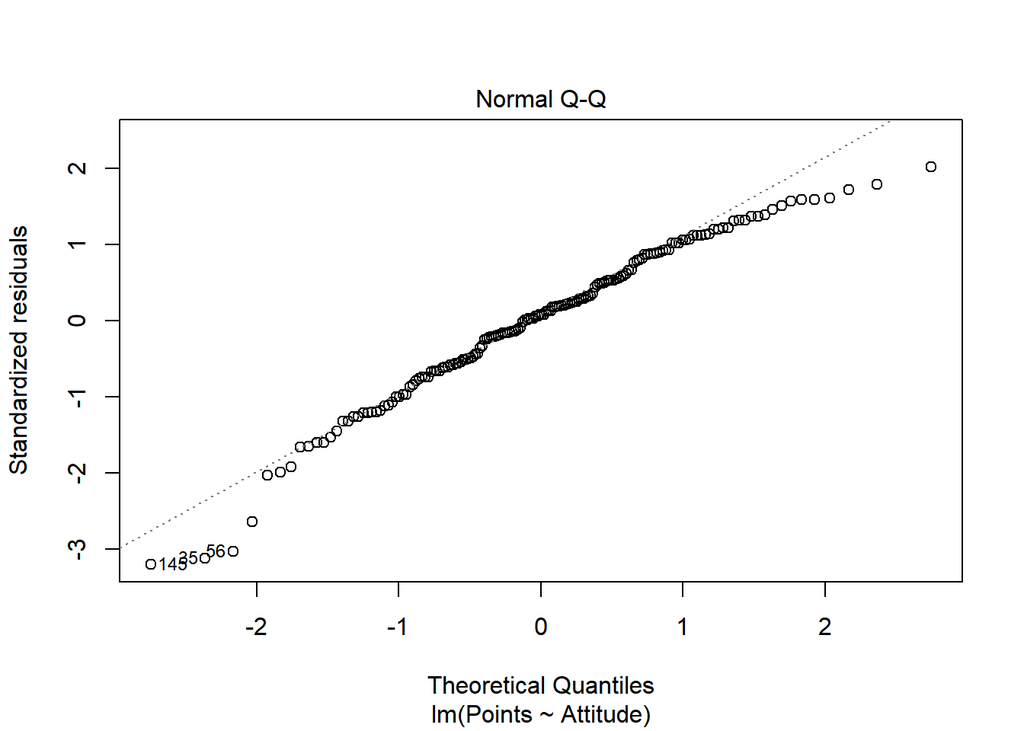

```r
plot(model, which=c(2))
```

The standardized residuals seem to fall on the line quite well, so we can assume that the errors are normally distributed (not perfect fit though, there’s a reason to be careful with this assumption).

**Residuals vs fitted values -graph for checking constant variance of errors**

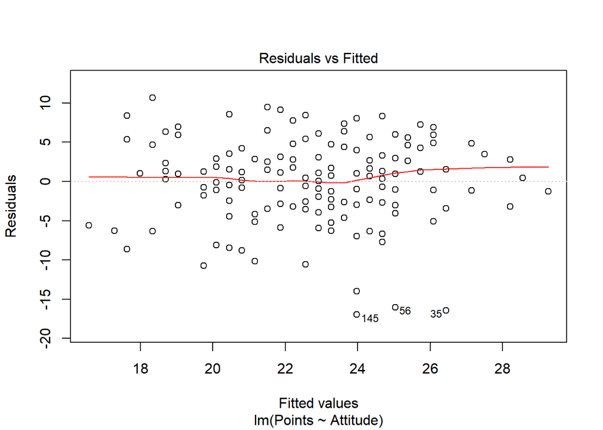

```r
plot(model, which=c(1))
```

There seems to be a decrease in the spreading of the residuals when the fitted values are very large,but this observation is based on so few datapoints that there is probably that I wouldn’t say it’s a clear sign against our assumption of constant variance of errors.

**Residuals vs leverage -graph for checking if a single pbservation has especially high impact on the model**

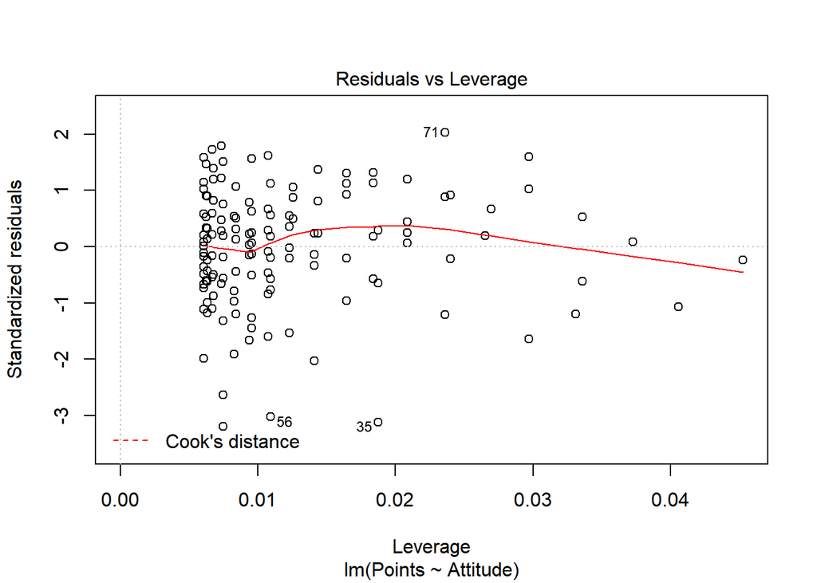

```r
plot(model, which=c(5))
```

No single point stands out from the graph, we are not likely to have observations that would have especially high impact on the model.